# Getting Started

Stars, Quasars, and Galaxies! All large luminous bodies in space! How do we classify them? I will use classification methods to try and classify them in this notebook.

What are stars, quasars, and galaxies? Let's look at Wikipedia for a quick introduction on what these objects are.

*Stars:* "An astronomical object comprising a luminous spheroid of plasma held together by its own gravity." ([About Stars](https://en.wikipedia.org/wiki/Star))

*Quasar*: "An extremely luminous active galactic nucleus (AGN), powered by a supermassive black hole, with mass ranging from millions to tens of billions of solar masses, surrounded by a gaseous accretion disc." ([About Quasars](https://en.wikipedia.org/wiki/Quasar))

*Galaxy*: "A gravitationally bound system of stars, stellar remnants, interstellar gas, dust, and dark matter." ([About Galaxies](https://en.wikipedia.org/wiki/Galaxy))

Before starting any sort of processing on our data, we need to import all of the libraries we will use as well as setting up the environment.

```python
# Imports
import numpy as np
import pandas as pd
import seaborn as sns
import math as m
from matplotlib import pyplot as plt

# Sklearn imports
from sklearn.preprocessing import LabelEncoder, MinMaxScaler
from sklearn.model_selection import train_test_split


# Chart set up
sns.set_theme(style="white", context="talk")

# Set up the matplotlib figure
sns.set(rc={"figure.figsize":(10,5)})

sns.despine(bottom=True)
```

```python
# Dataset setup
from google.colab import drive
drive.mount('/content/drive', force_remount=True)

import glob
import os

module_dir = '/content/drive/My Drive/Classes/Computer Science (General)/ITCS 3162/data/'

path = os.path.join(module_dir, 'star_classification.csv')

df = pd.read_csv(path)
```

Data from: https://www.kaggle.com/fedesoriano/stellar-classification-dataset-sdss17/version/1

Citation: fedesoriano. (January 2022). Stellar Classification Dataset - SDSS17. Retrieved 2-11-2022. from https://www.kaggle.com/fedesoriano/stellar-classification-dataset-sdss17.

## Initial visualizations

```python
df.head()
```

|  | obj_ID | alpha | delta | u | g | r | i | z | run_ID | rerun_ID | cam_col | field_ID | spec_obj_ID | class | redshift | plate | MJD | fiber_ID |
| --- | --- | --- | --- | --- | --- | --- | --- | --- | --- | --- | --- | --- | --- | --- | --- | --- | --- | --- |
| 0 | 1.237661e+18 | 135.689107 | 32.494632 | 23.87882 | 22.27530 | 20.39501 | 19.16573 | 18.79371 | 3606 | 301 | 2 | 79 | 6.543777e+18 | GALAXY | 0.634794 | 5812 | 56354 | 171 |
| 1 | 1.237665e+18 | 144.826101 | 31.274185 | 24.77759 | 22.83188 | 22.58444 | 21.16812 | 21.61427 | 4518 | 301 | 5 | 119 | 1.176014e+19 | GALAXY | 0.779136 | 10445 | 58158 | 427 |
| 2 | 1.237661e+18 | 142.188790 | 35.582444 | 25.26307 | 22.66389 | 20.60976 | 19.34857 | 18.94827 | 3606 | 301 | 2 | 120 | 5.152200e+18 | GALAXY | 0.644195 | 4576 | 55592 | 299 |
| 3 | 1.237663e+18 | 338.741038 | -0.402828 | 22.13682 | 23.77656 | 21.61162 | 20.50454 | 19.25010 | 4192 | 301 | 3 | 214 | 1.030107e+19 | GALAXY | 0.932346 | 9149 | 58039 | 775 |
| 4 | 1.237680e+18 | 345.282593 | 21.183866 | 19.43718 | 17.58028 | 16.49747 | 15.97711 | 15.54461 | 8102 | 301 | 3 | 137 | 6.891865e+18 | GALAXY | 0.116123 | 6121 | 56187 | 842 |

```python
df.columns
```

```
Index(['obj_ID', 'alpha', 'delta', 'u', 'g', 'r', 'i', 'z', 'run_ID',
       'rerun_ID', 'cam_col', 'field_ID', 'spec_obj_ID', 'class', 'redshift',
       'plate', 'MJD', 'fiber_ID'],
      dtype='object')
```

```python
df.shape
```

```
(100000, 18)
```

```python
df.dtypes
```

```
obj_ID         float64
alpha          float64
delta          float64
u              float64
g              float64
r              float64
i              float64
z              float64
run_ID           int64
rerun_ID         int64
cam_col          int64
field_ID         int64
spec_obj_ID    float64
class           object
redshift       float64
plate            int64
MJD              int64
fiber_ID         int64
dtype: object
```

```python
df.describe()
```

|  | obj_ID | alpha | delta | u | g | r | i | z | run_ID | rerun_ID | cam_col | field_ID | spec_obj_ID | redshift | plate | MJD | fiber_ID |
| --- | --- | --- | --- | --- | --- | --- | --- | --- | --- | --- | --- | --- | --- | --- | --- | --- | --- |
| count | 1.000000e+05 | 100000.000000 | 100000.000000 | 100000.000000 | 100000.000000 | 100000.000000 | 100000.000000 | 100000.000000 | 100000.000000 | 100000.0 | 100000.000000 | 100000.000000 | 1.000000e+05 | 100000.000000 | 100000.000000 | 100000.000000 | 100000.000000 |
| mean | 1.237665e+18 | 177.629117 | 24.135305 | 21.980468 | 20.531387 | 19.645762 | 19.084854 | 18.668810 | 4481.366060 | 301.0 | 3.511610 | 186.130520 | 5.783882e+18 | 0.576661 | 5137.009660 | 55588.647500 | 449.312740 |
| std | 8.438560e+12 | 96.502241 | 19.644665 | 31.769291 | 31.750292 | 1.854760 | 1.757895 | 31.728152 | 1964.764593 | 0.0 | 1.586912 | 149.011073 | 3.324016e+18 | 0.730707 | 2952.303351 | 1808.484233 | 272.498404 |
| min | 1.237646e+18 | 0.005528 | -18.785328 | -9999.000000 | -9999.000000 | 9.822070 | 9.469903 | -9999.000000 | 109.000000 | 301.0 | 1.000000 | 11.000000 | 2.995191e+17 | -0.009971 | 266.000000 | 51608.000000 | 1.000000 |
| 25% | 1.237659e+18 | 127.518222 | 5.146771 | 20.352353 | 18.965230 | 18.135828 | 17.732285 | 17.460677 | 3187.000000 | 301.0 | 2.000000 | 82.000000 | 2.844138e+18 | 0.054517 | 2526.000000 | 54234.000000 | 221.000000 |
| 50% | 1.237663e+18 | 180.900700 | 23.645922 | 22.179135 | 21.099835 | 20.125290 | 19.405145 | 19.004595 | 4188.000000 | 301.0 | 4.000000 | 146.000000 | 5.614883e+18 | 0.424173 | 4987.000000 | 55868.500000 | 433.000000 |
| 75% | 1.237668e+18 | 233.895005 | 39.901550 | 23.687440 | 22.123767 | 21.044785 | 20.396495 | 19.921120 | 5326.000000 | 301.0 | 5.000000 | 241.000000 | 8.332144e+18 | 0.704154 | 7400.250000 | 56777.000000 | 645.000000 |
| max | 1.237681e+18 | 359.999810 | 83.000519 | 32.781390 | 31.602240 | 29.571860 | 32.141470 | 29.383740 | 8162.000000 | 301.0 | 6.000000 | 989.000000 | 1.412694e+19 | 7.011245 | 12547.000000 | 58932.000000 | 1000.000000 |

Here is the key for each column in the data set listed on the dataset's kaggle page:

1. obj_ID = Object Identifier, the unique value that identifies the object in the image catalog used by the CAS
2. alpha = Right Ascension angle (at J2000 epoch)
3. delta = Declination angle (at J2000 epoch)
4. u = Ultraviolet filter in the photometric system
5. g = Green filter in the photometric system
6. r = Red filter in the photometric system
7. i = Near Infrared filter in the photometric system
8. z = Infrared filter in the photometric system
9. run_ID = Run Number used to identify the specific scan
10. rereun_ID = Rerun Number to specify how the image was processed
11. cam_col = Camera column to identify the scanline within the run
12. field_ID = Field number to identify each field
13. spec_obj_ID = Unique ID used for optical spectroscopic objects (this means that 2 different observations with the same spec_obj_ID must share the output class)
14. class = object class (galaxy, star or quasar object)
15. redshift = redshift value based on the increase in wavelength
16. plate = plate ID, identifies each plate in SDSS
17. MJD = Modified Julian Date, used to indicate when a given piece of SDSS data was taken
18. fiber_ID = fiber ID that identifies the fiber that pointed the light at the focal plane in each observation

# Data Cleaning and Preparation

We need to check the dataset for duplicate entries, imbalances, null values, standardize, and encode our class's names before going into the classification.

```python
# Check for duplicates and null values
print("Amount of Duplicates: %s\n" % (len(df) - len(df.drop_duplicates())))
print("Amount of Null Values:\n%s\n" % (df.isna().sum()))
```

```
Amount of Duplicates: 0

Amount of Null Values:
obj_ID         0
alpha          0
delta          0
u              0
g              0
r              0
i              0
z              0
run_ID         0
rerun_ID       0
cam_col        0
field_ID       0
spec_obj_ID    0
class          0
redshift       0
plate          0
MJD            0
fiber_ID       0
dtype: int64
```

Great! There is no null values or duplicates to worry about. Now we need to check if all of our data is necessary to build the model. As seen above, there is a lot of ID fields that can likely be dropped from the data set.

```python
# Drop all ID fields in the data and describe it
df = df.drop(['obj_ID','run_ID','rerun_ID','cam_col','field_ID','fiber_ID', 'MJD', 'plate'], axis = 1)
df.describe()
```

|  | alpha | delta | u | g | r | i | z | spec_obj_ID | redshift |
| --- | --- | --- | --- | --- | --- | --- | --- | --- | --- |
| count | 100000.000000 | 100000.000000 | 100000.000000 | 100000.000000 | 100000.000000 | 100000.000000 | 100000.000000 | 1.000000e+05 | 100000.000000 |
| mean | 177.629117 | 24.135305 | 21.980468 | 20.531387 | 19.645762 | 19.084854 | 18.668810 | 5.783882e+18 | 0.576661 |
| std | 96.502241 | 19.644665 | 31.769291 | 31.750292 | 1.854760 | 1.757895 | 31.728152 | 3.324016e+18 | 0.730707 |
| min | 0.005528 | -18.785328 | -9999.000000 | -9999.000000 | 9.822070 | 9.469903 | -9999.000000 | 2.995191e+17 | -0.009971 |
| 25% | 127.518222 | 5.146771 | 20.352353 | 18.965230 | 18.135828 | 17.732285 | 17.460677 | 2.844138e+18 | 0.054517 |
| 50% | 180.900700 | 23.645922 | 22.179135 | 21.099835 | 20.125290 | 19.405145 | 19.004595 | 5.614883e+18 | 0.424173 |
| 75% | 233.895005 | 39.901550 | 23.687440 | 22.123767 | 21.044785 | 20.396495 | 19.921120 | 8.332144e+18 | 0.704154 |
| max | 359.999810 | 83.000519 | 32.781390 | 31.602240 | 29.571860 | 32.141470 | 29.383740 | 1.412694e+19 | 7.011245 |

We can see that our data is all over the place in terms of min and max values. We need to standardize our data in order to not bias the model.

```python
'''
https://towardsdatascience.com/scale-standardize-or-normalize-with-scikit-learn-6ccc7d176a02
https://www.kaggle.com/discdiver/guide-to-scaling-and-standardizing

Standardize data using scikit learn min max scaler
Scikit Learn's min max scaler puts all values between 0 and 1
'''
mm_scaler = MinMaxScaler()
df_classes = df['class']
df_values = df[['alpha', 'delta', 'u', 'g', 'r', 'i', 'z', 'spec_obj_ID', 'redshift']]

col_names = list(df_values.columns)
df_mm = mm_scaler.fit_transform(df_values)
df_mm = pd.DataFrame(df_mm, columns=col_names)

df = pd.concat([df_classes, df_mm], axis=1)
```

We have gotten data that is not necessary for classification. Finally, it is time to check for imbalances in the amount of data points we have for a given class and encode their names.

```python
label_encoder = LabelEncoder()
df['class'] = label_encoder.fit_transform(df['class'])
```

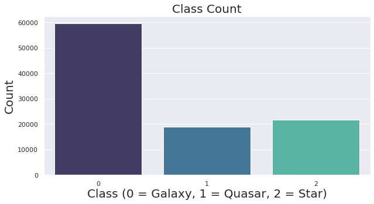

```python
# Check for ratio of classes
count_plot = sns.countplot(df["class"], palette="mako")
plt.title("Class Count",fontsize=20)
count_plot.set_ylabel("Count", fontsize = 20)
count_plot.set_xlabel("Class (0 = Galaxy, 1 = Quasar, 2 = Star)", fontsize = 20)
```

```python
'''
Galaxies = Class 0
Quasar = Class 1
Stars = Class 2
'''
df['class']. value_counts()
```

```
0    59445
2    21594
1    18961
Name: class, dtype: int64
```

# Training

We need to seperate our data and apply it to different models and balance out our data. As seen above, our data is extremely unbalanced! We need to rebalance it before training and testing.

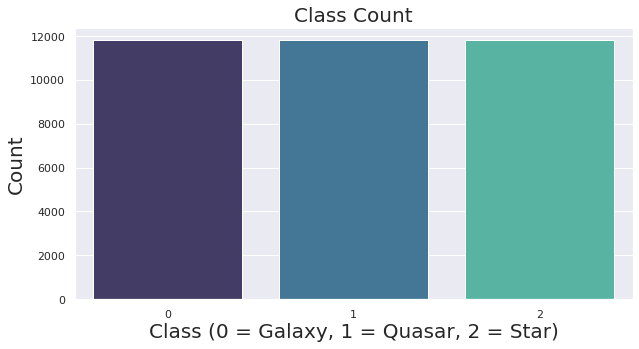

```python
'''
We are going to rebalance our data by oversampling the smaller classes.
This code is from an article on rebalancing imbalanced data

https://towardsdatascience.com/methods-for-dealing-with-imbalanced-data-5b761be45a18
'''
from sklearn.utils import resample

# Separate input features and target
x = df.drop(['class'], axis=1)
y = df['class']

# setting up testing and training sets
xtrain, xtest, ytrain, ytest = train_test_split(x, y, test_size=0.80)

# concatenate our training data back together
X = pd.concat([xtrain, ytrain], axis=1)

# separate minority and majority classes
galaxy = X[X['class'] == 0]
quasar = X[X['class'] == 1]
star = X[X['class'] == 2]

# upsample minority clases
upsampled_quasar = resample(quasar, replace=True, # sample with replacement
                            n_samples=len(galaxy)) # match number in majority class

upsampled_star = resample(star, replace=True, # sample with replacement
                          n_samples=len(galaxy)) # match number in majority class

# combine majority and upsampled minority
upsampled = pd.concat([galaxy, upsampled_quasar, upsampled_star])

# check new class counts
count_plot_new = sns.countplot(upsampled["class"], palette="mako")
plt.title("Class Count",fontsize=20)
count_plot_new.set_ylabel("Count", fontsize = 20)
count_plot_new.set_xlabel("Class (0 = Galaxy, 1 = Quasar, 2 = Star)", fontsize = 20)
```

This is much better! Time to get start spliting and training our data.

```python
# Split the data into x and y
x = upsampled.drop(['class'], axis=1)
y = upsampled['class']

x.shape, y.shape
```

```
((35469, 9), (35469,))
```

```python
# Split the data into training and testing data
xtrain, xtest, ytrain, ytest = train_test_split(x, y, test_size=0.80)

xtrain.shape, xtest.shape, ytrain.shape, ytest.shape
```

```
((7093, 9), (28376, 9), (7093,), (28376,))
```

Now that the data is split for training and later testing. We can fit it to our models.

```python
'''
Create our models

Code for creating the models is from Scikit-Learn demo (on canvas),
Scikit-Learn Cheat Sheet (on canvas), and from Scikit-Learn documentation

https://scikit-learn.org/stable/modules/generated/sklearn.ensemble.RandomForestClassifier.html
'''
from sklearn.tree import DecisionTreeClassifier
from sklearn.svm import SVC
from sklearn.naive_bayes import GaussianNB
from sklearn.neighbors import KNeighborsClassifier
from sklearn.ensemble import RandomForestClassifier

# Create our models
tree = DecisionTreeClassifier()
svc = SVC(kernel='linear')
gnb = GaussianNB()
knn = KNeighborsClassifier(n_neighbors=int(m.sqrt(xtrain.shape[0])))
clf = RandomForestClassifier()
```

Here are the classification algorithms we will be using on our data. Here is the list of algorithms I am using:

- Decision Tree (tree)

> A decision tree is an algorithm that tries to classify data based on a tree of conditional statements. Typically, the conditional statements yield true or false value and change how the data will branch through the rest of the tree.
- Support Vector Machine (svc)

> A Support Vector Machine, commonly abbreviated to SVM, is an algorithm that tries to find a hyperplane that can distinguish between different data classes/labels. The Hyperplane is a plane within a N-dimensional space, where N is the number of features of a data point in a given data set.
- Naive Bayes (gnb)

> Naive Bayes works is a classification algorithm that uses Bayes theorem to classify data. Naive Bayes classifies data using Bayes theorem by estimating the likelibood of a class/label for a given data point.
- K-Nearest Neighbors (knn)

> K-Nearest Neighbors is an algorithm that classifies piece of data by nearest neighbors' classes. The "K" in K-Nearest Neighbors tells us how many neighbors to look at around our data point.
- Random Forest (clf)

> Random Forest is an algorithm that uses multiple decision trees to classify a data point. Once a piece of data is ran through the trees, the class predicted by each tree is tallied. The class/label with the highest count is the predicted class for the data point.

[According to this article](https://towardsdatascience.com/a-simple-introduction-to-k-nearest-neighbors-algorithm-b3519ed98e#:~:text=5%20In%20general%2C%20practice%2C,samples%20in%20your%20training%20dataset%20.), the best K size is the square root of N, where N is the number of samples in the training dataset. Adapting this to my code, we can use the statement above to get the same result.

```python
# Fit our data to the models
tree.fit(xtrain, ytrain)
svc.fit(xtrain, ytrain)
gnb.fit(xtrain, ytrain)
knn.fit(xtrain, ytrain)
clf.fit(xtrain, ytrain)
```

```
RandomForestClassifier()
```

# Testing and Analysis

We have split the data and selected the models to test against our data. My hypothesis is that the K-Nearest Neighbors will be the best algorithm due to the fact that it creates clusters. Because we have three different classes in the data, I believe that the KNN algorithm will be able to create distinct clusters to accurately predict the class of each datapoint

```
[(0.0, 1.0)]
```

[figure not shown]

```python
# Import Metrics
from sklearn.metrics import accuracy_score

# Run our tests
y_prediction_tree = tree.predict(xtest)
y_prediction_svc = svc.predict(xtest)
y_prediction_gnb = gnb.predict(xtest)
y_prediction_knn = knn.predict(xtest)
y_prediction_clf = clf.predict(xtest)

# Compile the Accuracy Scores into dataframe
labels = ['Decision Tree', 'Support Vector Machine', 'Naive Bayes', 'K-Nearest Neighbors', 'Random Forest']

scores = []

scores.append(accuracy_score(ytest, y_prediction_tree))
scores.append(accuracy_score(ytest, y_prediction_svc))
scores.append(accuracy_score(ytest, y_prediction_gnb))
scores.append(accuracy_score(ytest, y_prediction_knn))
scores.append(accuracy_score(ytest, y_prediction_clf))

# Code for combining lists into dataframe from Geeks For Geeks
# https://www.geeksforgeeks.org/create-a-pandas-dataframe-from-lists/
accuracy_scores = pd.DataFrame(list(zip(labels, scores)),
                               columns=['algorithm', 'accuracy'])

# Generate chart
accuracy_chart = sns.barplot(data=accuracy_scores, x='algorithm', y='accuracy', palette="mako")
accuracy_chart.set_xlabel("Algorithm Name", fontsize = 20)
accuracy_chart.set_ylabel("Accuracy [0.0, 1.0]", fontsize = 20)
accuracy_chart.set_title("Accuray of Classification Algorithms on Stellar Objects", fontsize = 20)
accuracy_chart.set(ylim=(0, 1))
```

```python
from sklearn.metrics import classification_report, confusion_matrix

# Get all classification reports
tree_report = classification_report(ytest, y_prediction_tree, output_dict=True)
svc_report = classification_report(ytest, y_prediction_svc, output_dict=True)
gnb_report = classification_report(ytest, y_prediction_gnb, output_dict=True)
knn_report = classification_report(ytest, y_prediction_knn, output_dict=True)
clf_report = classification_report(ytest, y_prediction_clf, output_dict=True)
```

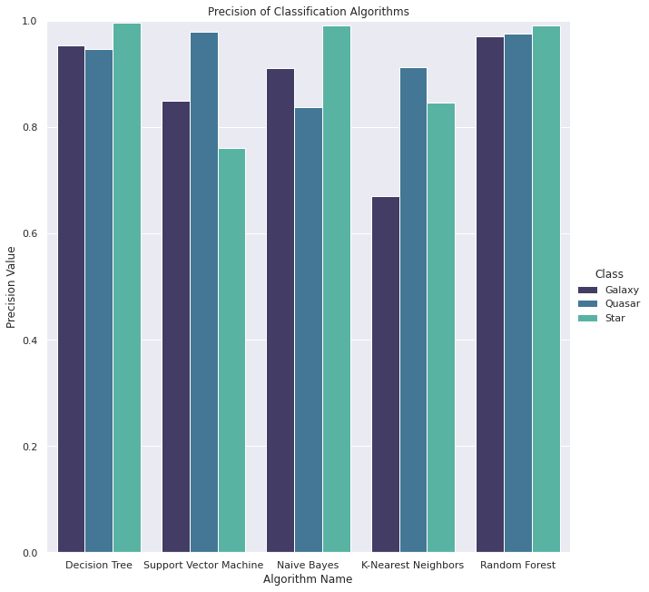

```python
# Create graphs by precision, recall, and f1-score
reports = pd.DataFrame({'algorithm' :
                           [
                            'Decision Tree', 'Decision Tree', 'Decision Tree',
                            'Support Vector Machine', 'Support Vector Machine', 'Support Vector Machine',
                            'Naive Bayes', 'Naive Bayes','Naive Bayes',
                            'K-Nearest Neighbors', 'K-Nearest Neighbors', 'K-Nearest Neighbors',
                            'Random Forest', 'Random Forest', 'Random Forest'
                           ],
                           'precision' :
                           [
                            tree_report['0']['precision'], tree_report['1']['precision'], tree_report['2']['precision'],
                            svc_report['0']['precision'], svc_report['1']['precision'], svc_report['2']['precision'],
                            gnb_report['0']['precision'], gnb_report['1']['precision'], gnb_report['2']['precision'],
                            knn_report['0']['precision'], knn_report['1']['precision'], knn_report['2']['precision'],
                            clf_report['0']['precision'], clf_report['1']['precision'], clf_report['2']['precision'],
                           ],
                           'recall' :
                           [
                            tree_report['0']['recall'], tree_report['1']['recall'], tree_report['2']['recall'],
                            svc_report['0']['recall'], svc_report['1']['recall'], svc_report['2']['recall'],
                            gnb_report['0']['recall'], gnb_report['1']['recall'], gnb_report['2']['recall'],
                            knn_report['0']['recall'], knn_report['1']['recall'], knn_report['2']['recall'],
                            clf_report['0']['recall'], clf_report['1']['recall'], clf_report['2']['recall'],
                           ],
                           'f1Scores' :
                           [
                            tree_report['0']['f1-score'], tree_report['1']['f1-score'], tree_report['2']['f1-score'],
                            svc_report['0']['f1-score'], svc_report['1']['f1-score'], svc_report['2']['f1-score'],
                            gnb_report['0']['f1-score'], gnb_report['1']['f1-score'], gnb_report['2']['f1-score'],
                            knn_report['0']['f1-score'], knn_report['1']['f1-score'], knn_report['2']['f1-score'],
                            clf_report['0']['f1-score'], clf_report['1']['f1-score'], clf_report['2']['f1-score'],
                           ],
                           'class' :
                           [
                            'Galaxy', 'Quasar', 'Star',
                            'Galaxy', 'Quasar', 'Star',
                            'Galaxy', 'Quasar', 'Star',
                            'Galaxy', 'Quasar', 'Star',
                            'Galaxy', 'Quasar', 'Star'
                           ]
                          })

precision_chart = sns.catplot(x="algorithm", y="precision", hue="class", kind="bar", data=reports, palette="mako", height=9)
precision_chart.set_axis_labels("Algorithm Name", "Precision Value")
precision_chart.legend.set_title("Class")
plt.title('Precision of Classification Algorithms')
precision_chart.set(ylim=(0, 1))
```

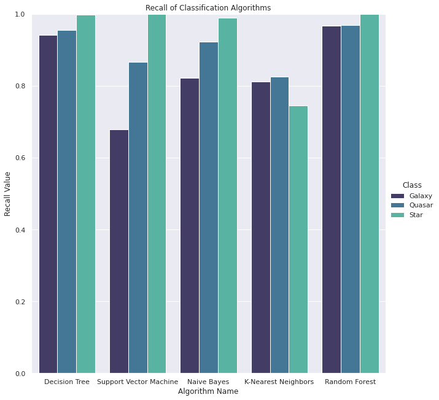

```python
recall_chart = sns.catplot(x="algorithm", y="recall", hue="class", kind="bar", data=reports, palette="mako", height=9)
recall_chart.set_axis_labels("Algorithm Name", "Recall Value")
recall_chart.legend.set_title("Class")
plt.title('Recall of Classification Algorithms')
recall_chart.set(ylim=(0, 1))
```